# Swiggy Restaurant Data Visualization

## 4. Execute All Visualizations

Now we will run all the visualization functions one by one to generate the plots and insights.

### 4.1 Price Distribution

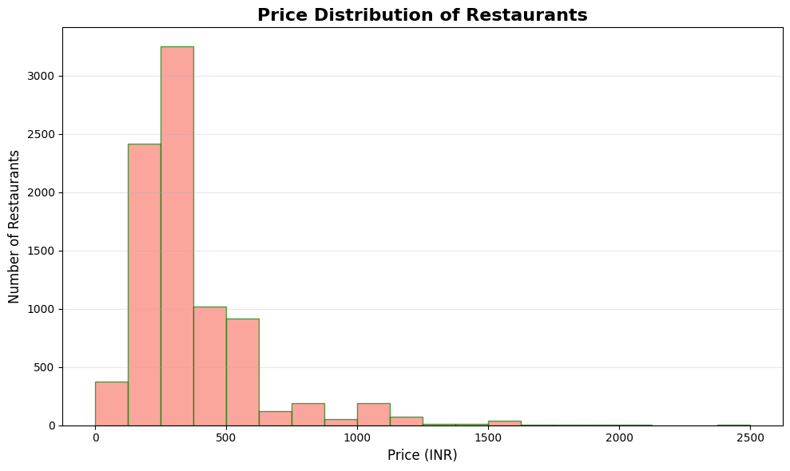

```
============================================================
PRICE DISTRIBUTION INSIGHTS
============================================================
Minimum Price: ₹0
Maximum Price: ₹2500
Average Price: ₹348.44
Median Price: ₹300.00
Most restaurants have prices between ₹200 and ₹600
============================================================
```

```python
visualize_price_distribution()
```

### 4.2 Ratings Distribution

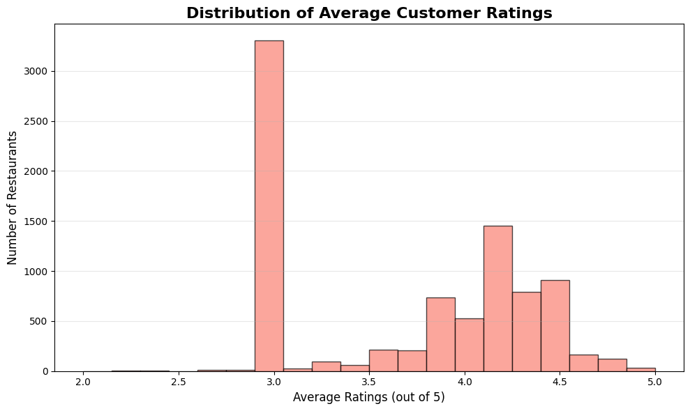

[output not shown]

```python
visualize_ratings_distribution()
```

### 4.3 Delivery Time Distribution

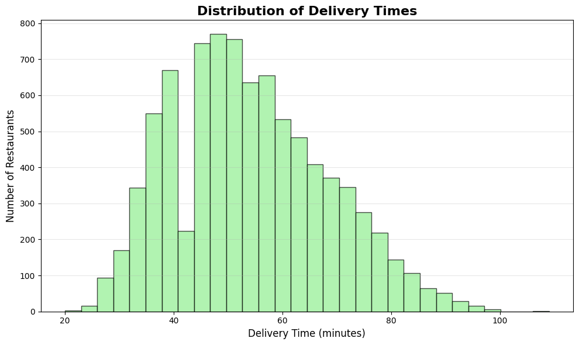

```
============================================================
DELIVERY TIME INSIGHTS
============================================================
Minimum Delivery Time: 20 minutes
Maximum Delivery Time: 109 minutes
Average Delivery Time: 53.97 minutes
Median Delivery Time: 53.00 minutes
Most deliveries are promised within 30-70 minutes
============================================================
```

```python
visualize_delivery_time_distribution()
```

### 4.4 Top Cities by Restaurant Count

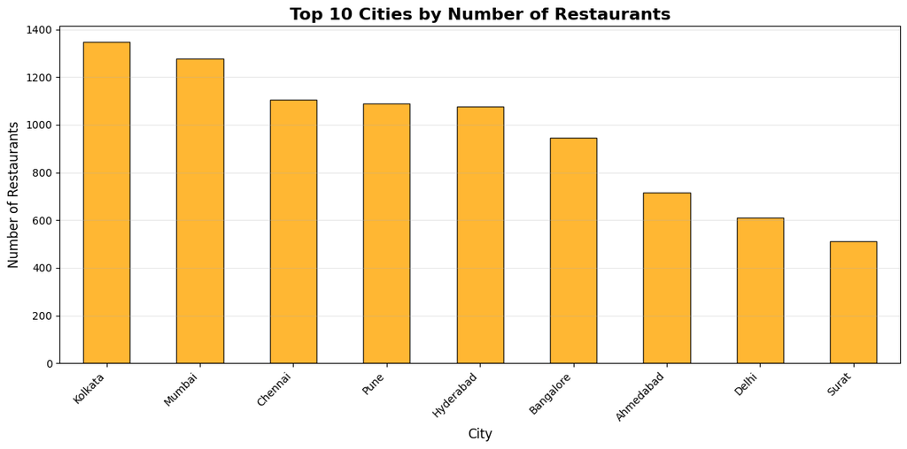

```
============================================================
TOP CITIES INSIGHTS
============================================================
1. Kolkata: 1346 restaurants
2. Mumbai: 1277 restaurants
3. Chennai: 1106 restaurants
4. Pune: 1090 restaurants
5. Hyderabad: 1075 restaurants
6. Bangalore: 946 restaurants
7. Ahmedabad: 717 restaurants
8. Delhi: 611 restaurants
9. Surat: 512 restaurants

Major metropolitan cities dominate the restaurant market
============================================================
```

```python
visualize_top_cities()
```

### 4.5 Top Areas by Restaurant Count

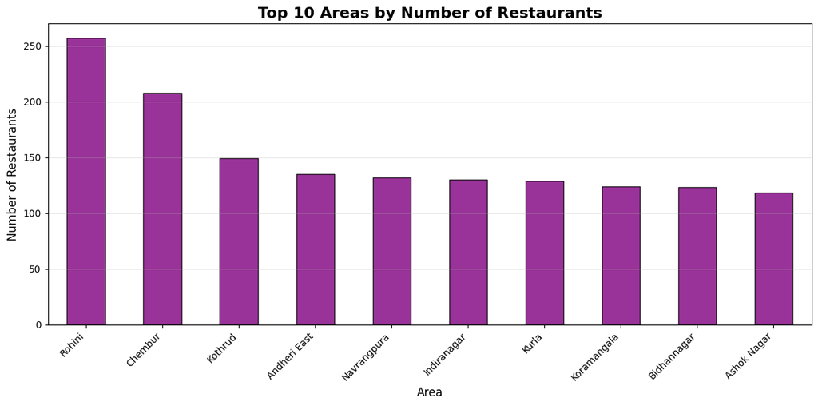

```
============================================================
TOP AREAS INSIGHTS
============================================================
1. Rohini: 257 restaurants
2. Chembur: 208 restaurants
3. Kothrud: 149 restaurants
4. Andheri East: 135 restaurants
5. Navrangpura: 132 restaurants
6. Indiranagar: 130 restaurants
7. Kurla: 129 restaurants
8. Koramangala: 124 restaurants
9. Bidhannagar: 123 restaurants
10. Ashok Nagar: 118 restaurants

Certain popular localities are restaurant hotspots
============================================================
```

```python
visualize_top_areas()
```

### 4.6 Most Common Food Types

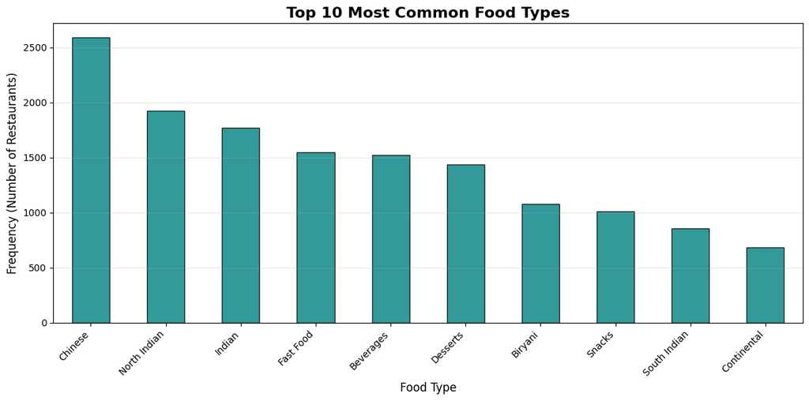

[output not shown]

```python
visualize_common_food_types()
```

### 4.7 Correlation Matrix

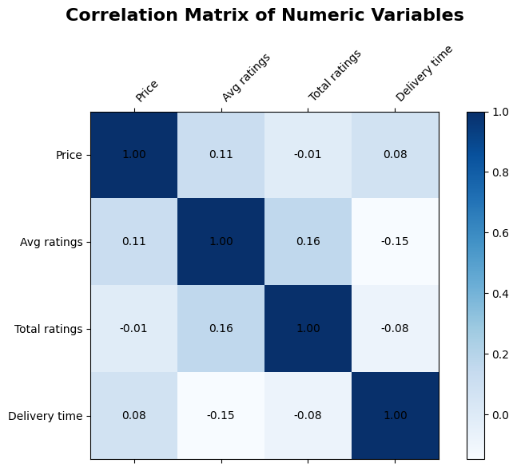

```
============================================================
CORRELATION MATRIX INSIGHTS
============================================================
Correlation values range from -1 to 1:
  • 1 = Perfect positive correlation
  • 0 = No correlation
  • -1 = Perfect negative correlation

Key Findings:
  • Numeric columns show only weak correlations with each other
  • Price and ratings are not strongly correlated
============================================================
```

```python
visualize_correlation_matrix()
```

### 4.8 Price by City (Boxplot)

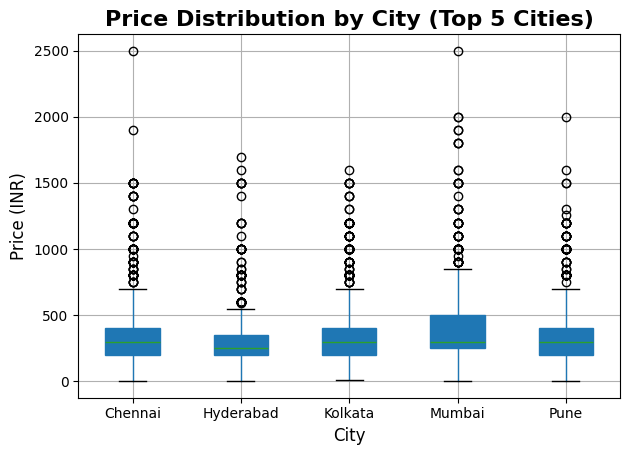

```
============================================================
PRICE BY CITY INSIGHTS
============================================================

Kolkata:
  • Median Price: ₹300.00
  • Average Price: ₹362.29
  • Price Range: ₹10 - ₹1600

Mumbai:
  • Median Price: ₹300.00
  • Average Price: ₹393.79
  • Price Range: ₹1 - ₹2500

Chennai:
  • Median Price: ₹300.00
  • Average Price: ₹356.25
  • Price Range: ₹0 - ₹2500

Pune:
  • Median Price: ₹300.00
  • Average Price: ₹353.76
  • Price Range: ₹1 - ₹2000

Hyderabad:
  • Median Price: ₹250.00
  • Average Price: ₹299.93
  • Price Range: ₹2 - ₹1700

Some cities have higher price spreads than others
============================================================
```

```python
visualize_price_by_city_boxplot()
```

### 4.9 Price vs Ratings

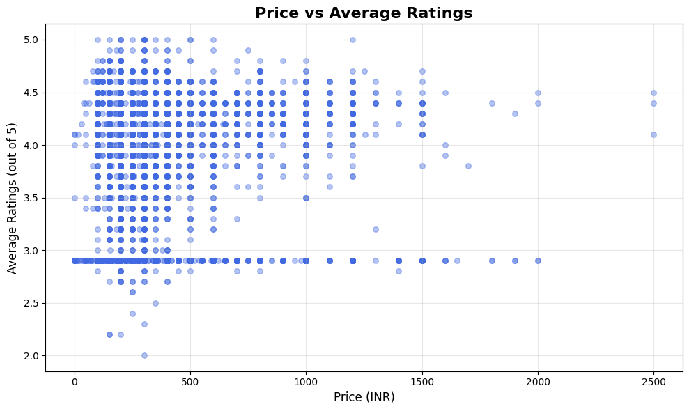

```
============================================================
PRICE VS RATINGS INSIGHTS
============================================================
The scatter plot shows:
  • No clear linear relationship between price and ratings
  • Good ratings exist across all price ranges
  • Expensive doesn't always mean better rated
  • Customer satisfaction depends on factors beyond price
============================================================
```

```python
visualize_price_vs_ratings()
```

### 4.10 Ratings by Food Type

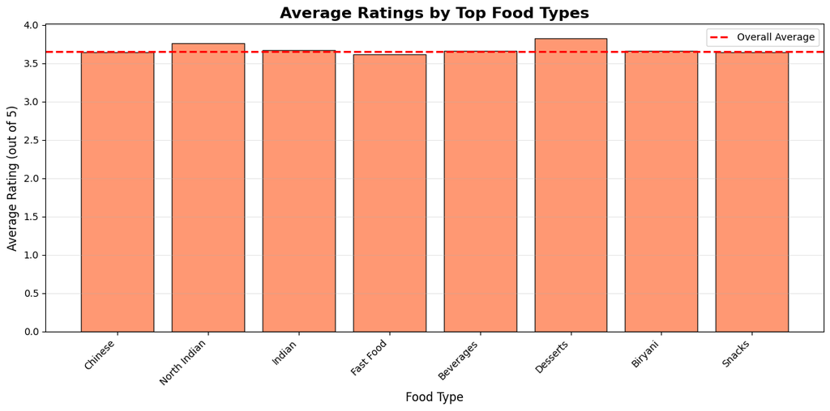

[output not shown]

```python
visualize_ratings_by_food_type()
```

### 4.11 City Distribution (Pie Chart)

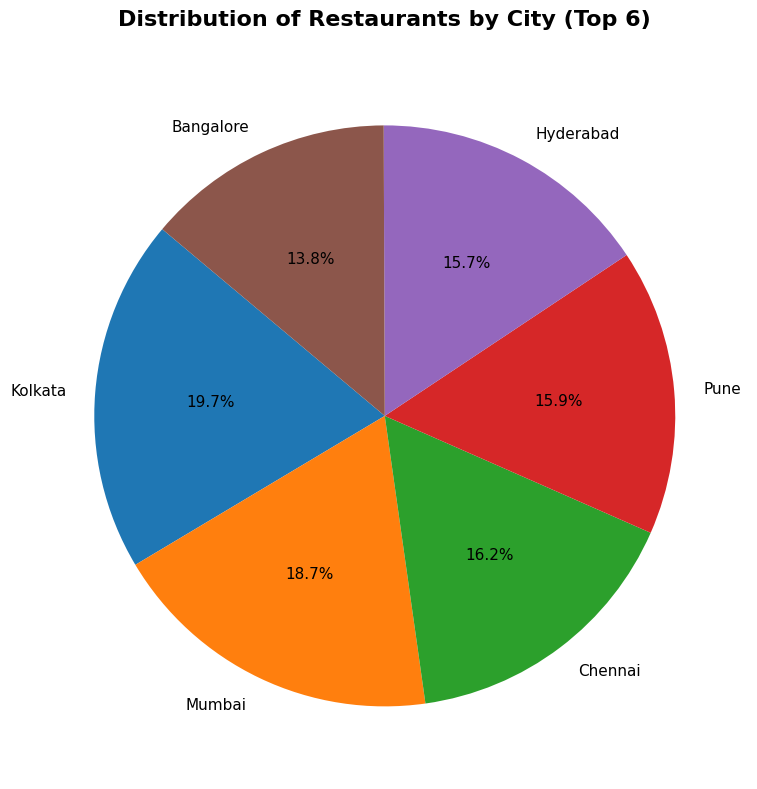

```
============================================================
CITY DISTRIBUTION INSIGHTS
============================================================
Kolkata: 1346 restaurants (15.5% of dataset)
Mumbai: 1277 restaurants (14.7% of dataset)
Chennai: 1106 restaurants (12.7% of dataset)
Pune: 1090 restaurants (12.6% of dataset)
Hyderabad: 1075 restaurants (12.4% of dataset)
Bangalore: 946 restaurants (10.9% of dataset)

Top 6 cities account for 78.8% of all restaurants
Restaurant market is dominated by few metropolitan cities
============================================================
```

```python
visualize_city_distribution_pie()
```

### 4.12 Average Price by City

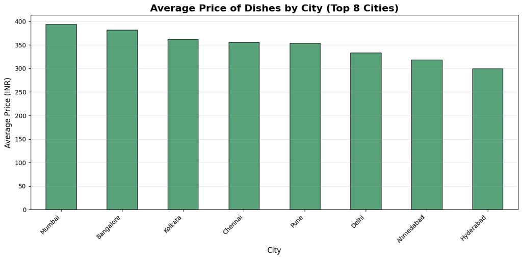

```
============================================================
AVERAGE PRICE BY CITY INSIGHTS
============================================================
1. Mumbai: ₹393.79
2. Bangalore: ₹382.52
3. Kolkata: ₹362.29
4. Chennai: ₹356.25
5. Pune: ₹353.76
6. Delhi: ₹333.30
7. Ahmedabad: ₹318.13
8. Hyderabad: ₹299.93

Overall Average Price: ₹348.44
Some cities have consistently higher average prices
============================================================
```

```python
visualize_avg_price_by_city()
```

### 4.13 Delivery Time Buckets

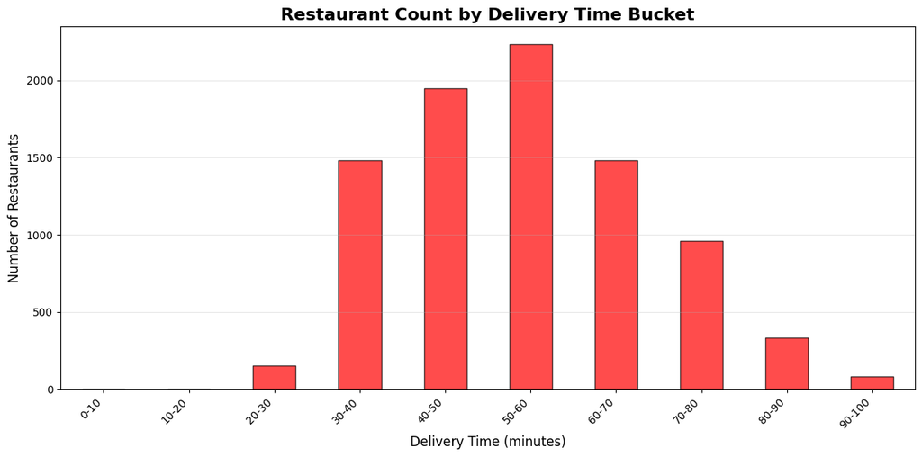

[output not shown]

```python
visualize_delivery_time_buckets()
```

## 5. Conclusion

### Methodology:

This analysis was conducted using:

- **Python 3.x** for programming
- **Pandas** for data manipulation and analysis
- **Matplotlib** for creating visualizations
- **NumPy** for numerical computations

### Dataset Summary:

- **Total Restaurants**: 8,680
- **Cities Covered**: 9
- **Areas Covered**: 833
- **Data Completeness**: 100% (no missing values)

**Project completed successfully!**

*This project demonstrates the power of data visualization in understanding business metrics and customer behavior patterns on food delivery platforms.*